# Crop Yield EDA

Elizabeth Giles

2025-03-01

```r
library(tidyverse)
setwd("C:/Users/lizgi/Downloads/")
crop_yield <- read.csv("crop_yield.csv")
str(crop_yield)
```

```
## 'data.frame':    19689 obs. of  10 variables:
##  $ Crop           : chr  "Arecanut" "Arhar/Tur" "Castor seed" "Coconut " ...
##  $ Crop_Year      : int  1997 1997 1997 1997 1997 1997 1997 1997 1997 1997 ...
##  $ Season         : chr  "Whole Year " "Kharif     " "Kharif     " "Whole Year " ...
##  $ State          : chr  "Assam" "Assam" "Assam" "Assam" ...
##  $ Area           : num  73814 6637 796 19656 1739 ...
##  $ Production     : num  5.67e+04 4.68e+03 2.20e+01 1.27e+08 7.94e+02 ...
##  $ Annual_Rainfall: num  2051 2051 2051 2051 2051 ...
##  $ Fertilizer     : num  7024878 631643 75755 1870662 165501 ...
##  $ Pesticide      : num  22882 2057 247 6093 539 ...
##  $ Yield          : num  0.796 0.71 0.238 5238.052 0.421 ...
```

```r
head(crop_yield)
```

```
##           Crop Crop_Year      Season State  Area Production Annual_Rainfall
## 1     Arecanut      1997 Whole Year  Assam 73814      56708          2051.4
## 2    Arhar/Tur      1997 Kharif      Assam  6637       4685          2051.4
## 3  Castor seed      1997 Kharif      Assam   796         22          2051.4
## 4     Coconut       1997 Whole Year  Assam 19656  126905000          2051.4
## 5 Cotton(lint)      1997 Kharif      Assam  1739        794          2051.4
## 6 Dry chillies      1997 Whole Year  Assam 13587       9073          2051.4
##   Fertilizer Pesticide        Yield
## 1 7024878.38  22882.34    0.7960870
## 2  631643.29   2057.47    0.7104348
## 3   75755.32    246.76    0.2383333
## 4 1870661.52   6093.36 5238.0517390
## 5  165500.63    539.09    0.4209091
## 6 1293074.79   4211.97    0.6436364
```

```r
summary(crop_yield)
```

```
##      Crop             Crop_Year       Season             State
##  Length:19689       Min.   :1997   Length:19689       Length:19689
##  Class :character   1st Qu.:2004   Class :character   Class :character
##  Mode  :character   Median :2010   Mode  :character   Mode  :character
##                     Mean   :2009
##                     3rd Qu.:2015
##                     Max.   :2020
##       Area            Production        Annual_Rainfall    Fertilizer
##  Min.   :       0   Min.   :0.000e+00   Min.   : 301.3   Min.   :5.400e+01
##  1st Qu.:    1390   1st Qu.:1.393e+03   1st Qu.: 940.7   1st Qu.:1.880e+05
##  Median :    9317   Median :1.380e+04   Median :1247.6   Median :1.235e+06
##  Mean   :  179927   Mean   :1.644e+07   Mean   :1437.8   Mean   :2.410e+07
##  3rd Qu.:   75112   3rd Qu.:1.227e+05   3rd Qu.:1643.7   3rd Qu.:1.000e+07
##  Max.   :50808100   Max.   :6.326e+09   Max.   :6552.7   Max.   :4.835e+09
##    Pesticide            Yield
##  Min.   :       0   Min.   :    0.000
##  1st Qu.:     357   1st Qu.:    0.600
##  Median :    2422   Median :    1.030
##  Mean   :   48848   Mean   :   79.954
##  3rd Qu.:   20042   3rd Qu.:    2.389
##  Max.   :15750511   Max.   :21105.000
```

Crop: The name of the crop cultivated. Crop_Year: The year in which the crop was grown. Season: The specific cropping season State: The Indian state where the crop was cultivated. Area: The total land area (in hectares) under cultivation for the specific crop. Production: The quantity of crop production (in metric tons). Annual_Rainfall: The annual rainfall received in the crop-growing region (in mm). Fertilizer: The total amount of fertilizer used for the crop (in kilograms). Pesticide: The total amount of pesticide used for the crop (in kilograms). Yield: The calculated crop yield (production per unit area).

```r
crop_yield_view <- arrange(crop_yield, Crop, Crop_Year, Season, State)
table(crop_yield$Crop)
```

```
##
##              Arecanut             Arhar/Tur                 Bajra
##                   162                   508                   524
##                Banana                Barley          Black pepper
##                   245                   297                   126
##              Cardamom             Cashewnut           Castor seed
##                    74                   134                   300
##              Coconut              Coriander          Cotton(lint)
##                   172                   199                   476
##         Cowpea(Lobia)          Dry chillies                Garlic
##                   134                   419                   250
##                Ginger                  Gram             Groundnut
##                   323                   490                   725
##             Guar seed            Horse-gram                 Jowar
##                    63                   371                   513
##                  Jute               Khesari               Linseed
##                   181                    75                   308
##                 Maize                Masoor                 Mesta
##                   975                   324                   210
##     Moong(Green Gram)                  Moth            Niger seed
##                   740                   110                   192
##        Oilseeds total                 Onion    Other  Rabi pulses
##                    29                   454                   355
##         Other Cereals   Other Kharif pulses        other oilseeds
##                   146                   382                   126
##   Other Summer Pulses Peas & beans (Pulses)                Potato
##                    10                   369                   628
##                  Ragi     Rapeseed &Mustard                  Rice
##                   498                   528                  1197
##             Safflower              Sannhamp               Sesamum
##                   169                   160                   685
##         Small millets              Soyabean             Sugarcane
##                   485                   349                   605
##             Sunflower          Sweet potato               Tapioca
##                   441                   273                   201
##               Tobacco              Turmeric                  Urad
##                   364                   337                   733
##                 Wheat
##                   545
```

About 55 different crop entries

```r
table(crop_yield$State)
```

```
##
##    Andhra Pradesh Arunachal Pradesh             Assam             Bihar
##              1266               292               731               896
##      Chhattisgarh             Delhi               Goa           Gujarat
##               915               203               246               817
##           Haryana  Himachal Pradesh Jammu and Kashmir         Jharkhand
##               631               616               631               270
##         Karnataka            Kerala    Madhya Pradesh       Maharashtra
##              1432               534               845               770
##           Manipur         Meghalaya           Mizoram          Nagaland
##               444               649               416               689
##            Odisha        Puducherry            Punjab            Sikkim
##               760               670               397               226
##        Tamil Nadu         Telangana           Tripura     Uttar Pradesh
##               822               397               441               825
##       Uttarakhand       West Bengal
##               764              1094
```

```r
table(crop_yield$Season)
```

```
##
## Autumn      Kharif      Rabi        Summer      Whole Year  Winter
##         414        8232        5742        1195        3717         389
```

Five seasons plus whole year

Info from the internet Kharif - crops are sown early-May – usually at the beginning of the first monsoon rain Rabi - crops are sown around mid-November – preferably after the monsoon rains

South-west monsoon lasting from June to September. The season is dominated by the humid southwest summer monsoon, which slowly sweeps across the country beginning in late May or early June. Monsoon rains begin to recede from North India at the beginning of October.

```r
table(crop_yield$Crop_Year)
```

```
##
## 1997 1998 1999 2000 2001 2002 2003 2004 2005 2006 2007 2008 2009 2010 2011 2012
##  410  646  650  772  750  815  801  787  811  823  828  847  865  859  907  894
## 2013 2014 2015 2016 2017 2018 2019 2020
##  976  965  998 1036 1070 1063 1079   37
```

Only a few observations of year 2020 (will likely skew plots)

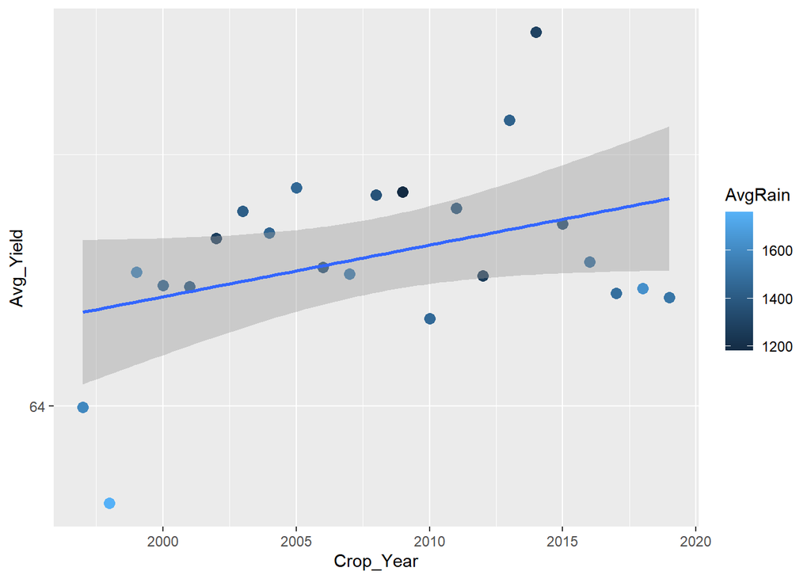

```r
groupedYear <- group_by(crop_yield, Crop_Year)


YearYield <- summarize(groupedYear, Avg_Yield = mean(Yield), AvgRain = mean(Annual_Rainfall), AvgPest = mean(Pesticide), AvgFert = mean(Fertilizer))



plotYear = filter(YearYield, Crop_Year != "2020")
ggplot(plotYear, aes(Crop_Year, Avg_Yield, color = AvgRain)) +
  geom_point(size=3) + scale_y_continuous(trans = 'log2') +
  geom_smooth(method="lm")
```

```r
#ggsave("plot01.png")
```

Positive trend in yield mean (I realize I used an old saved plot for my presentation and did not notice till I was up there sorry) Noticed there’s no correlation in rain average

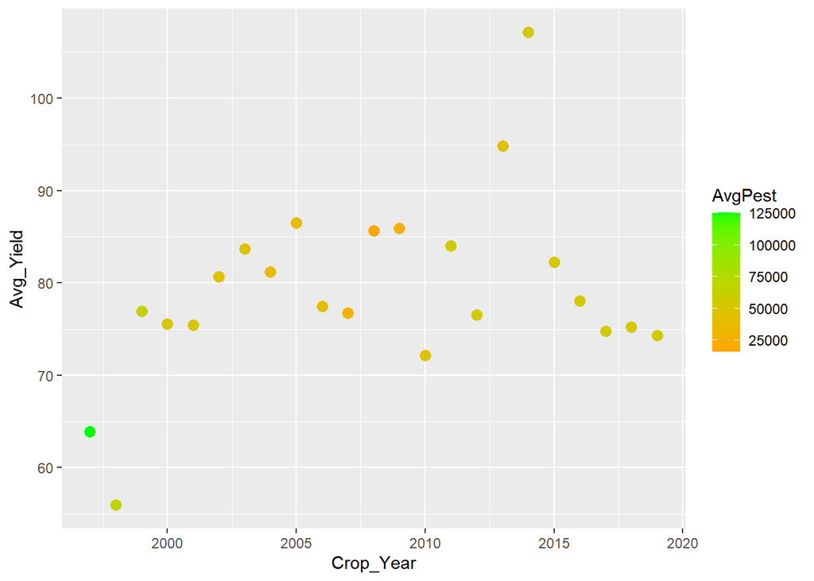

```r
ggplot(plotYear, aes(Crop_Year, Avg_Yield, color = AvgPest)) +
  geom_point(size=3) + scale_color_gradient(low="orange", high="green")
```

No noticeably visual correlation between pesticide and yield

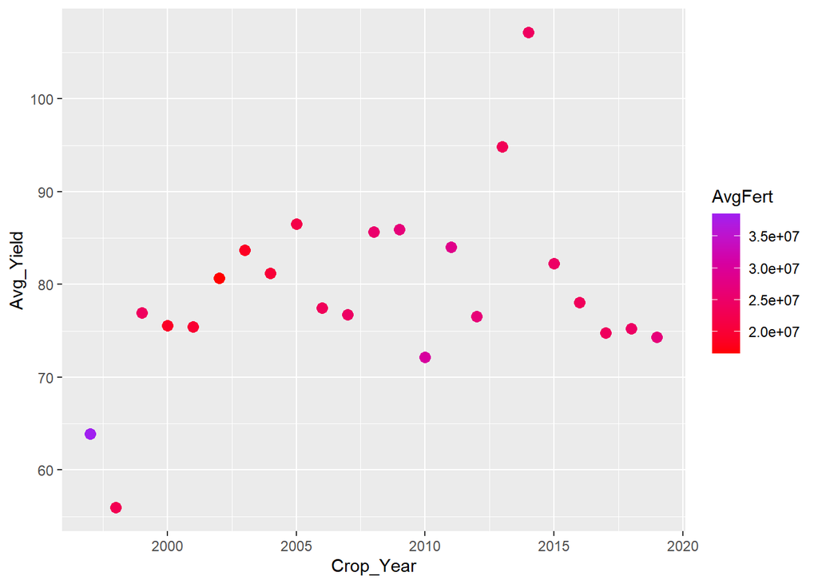

```r
ggplot(plotYear, aes(Crop_Year, Avg_Yield, color = AvgFert)) +
  geom_point(size=3) + scale_color_gradient(low="red", high="purple")
```

No visual correlation between fertilizer and yield

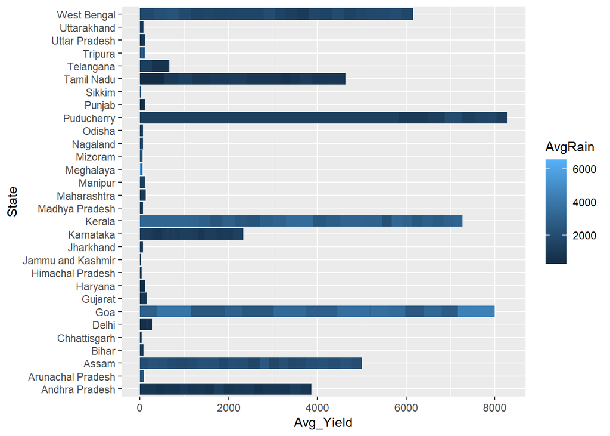

```r
YearState <- group_by(crop_yield, Crop_Year, State)
YearStateStats <- summarise(YearState, Avg_Yield = mean(Yield), AvgRain = mean(Annual_Rainfall), AvgPest = mean(Pesticide), AvgFert = mean(Fertilizer), .groups = "keep")

  ggplot(YearStateStats, aes(y= State, x= Avg_Yield, fill = AvgRain)) +
  geom_bar(stat = "identity")
```

```r
  #ggsave("plot02.png")
```

Major difference in production. Note most States with higher yields are coastal states. Some have higher rainfall but some like Puducherry don’t and a lot more

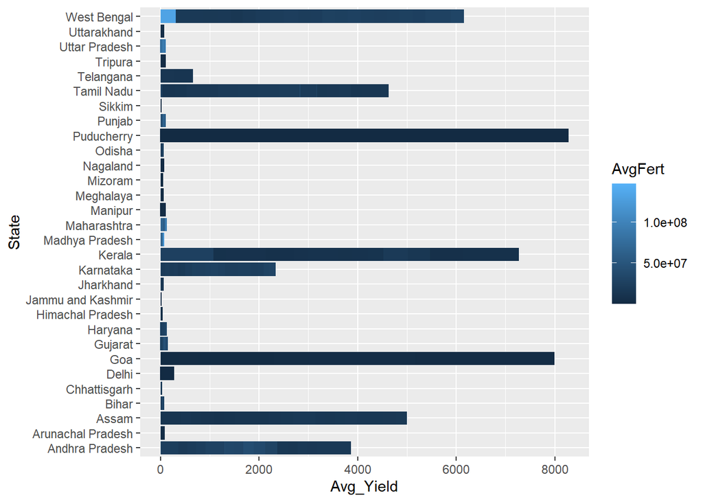

```r
ggplot(YearStateStats, aes(y= State, x= Avg_Yield, fill = AvgFert)) +
  geom_bar(stat = "identity")
```

Fertilizer has no visual correlation

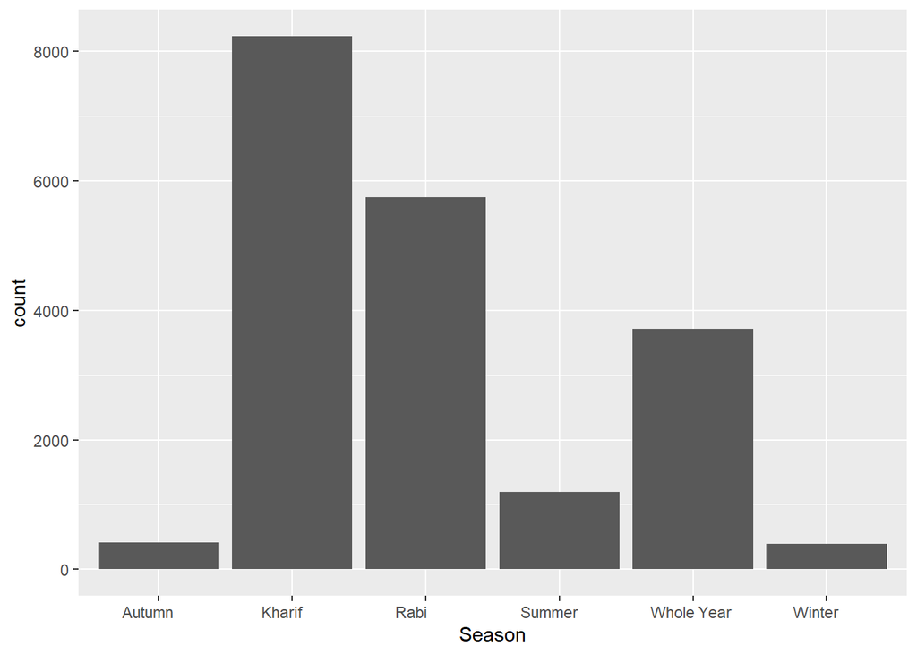

```r
ggplot(crop_yield, aes(Season)) +
  geom_bar()
```

```r
ggsave("plot03.png")
```

Rabi and Kharif are the most popular seasons

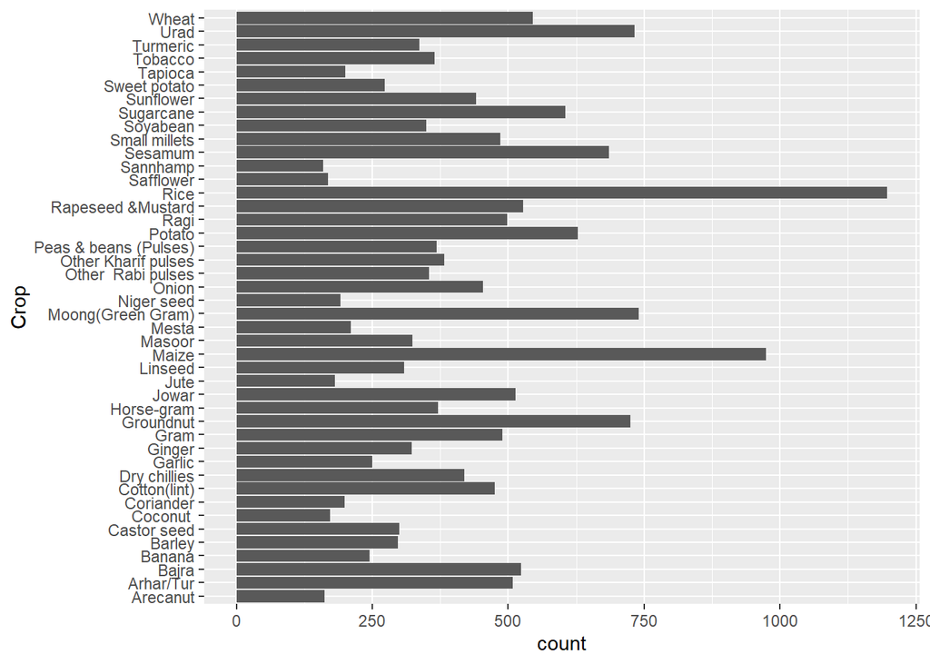

```r
crop_yield %>%
group_by(Crop) %>%
summarise(count = n()) -> cropNums

mainCrops <- filter(cropNums, count > 150)

ggplot(mainCrops, aes(x = Crop, y = count)) +
  geom_bar(stat = "identity") + coord_flip()
```

```r
ggsave("plot04.png")
```

filtered down to 150 since a lot of the entries had just a few entries making a really messy plot I just want to see the more popular crops

```r
mainSeasons <- c("Kharif", "Rabi", "Whole Year")
mainStates <- c("West Bengal", "Telangana", "Tamil Nadu", "Puducherry", "Kerala", "Karnataka", "Goa", "Assam", "Andhra Pradesh")
```

Separating data

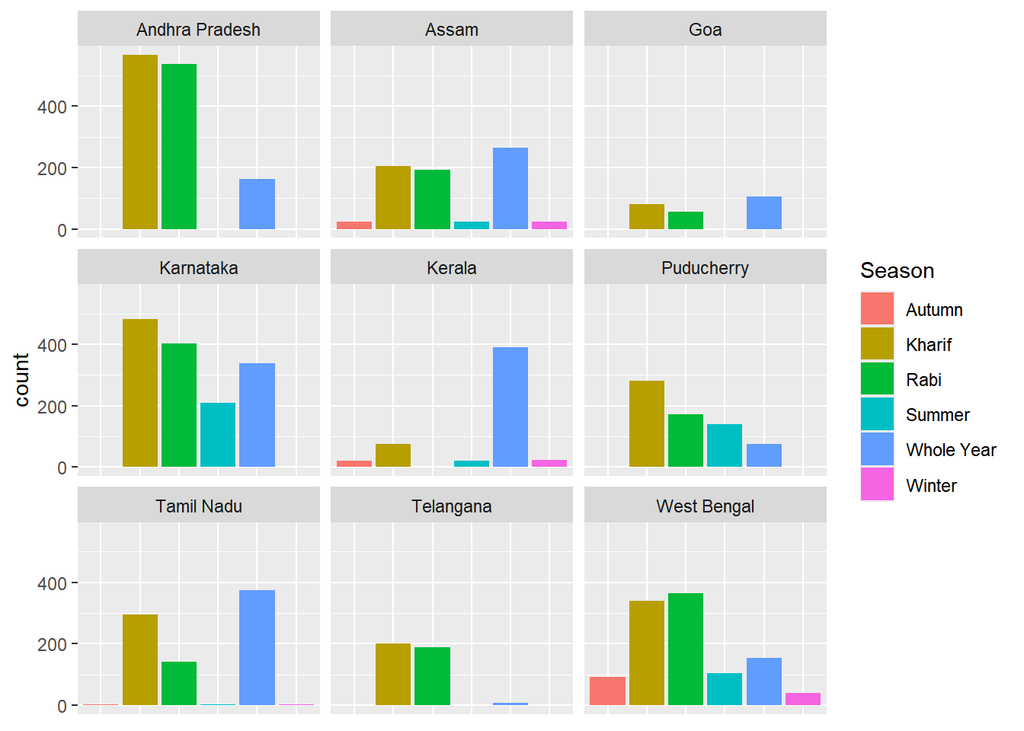

```r
newYear <- filter(crop_yield, State %in% mainStates)
#newYear <- filter(newYear, Season %in% mainSeasons)
newYear <- group_by(newYear, Crop_Year, State, Season, Crop)
ggplot(newYear, aes(Season, fill = Season)) +
  geom_bar() + facet_wrap(~State) + theme(
    axis.title.x = element_blank(),
    axis.text.x = element_blank(),
    axis.ticks.x = element_blank()
  )
```

```r
#ggsave("plot05.png")
```

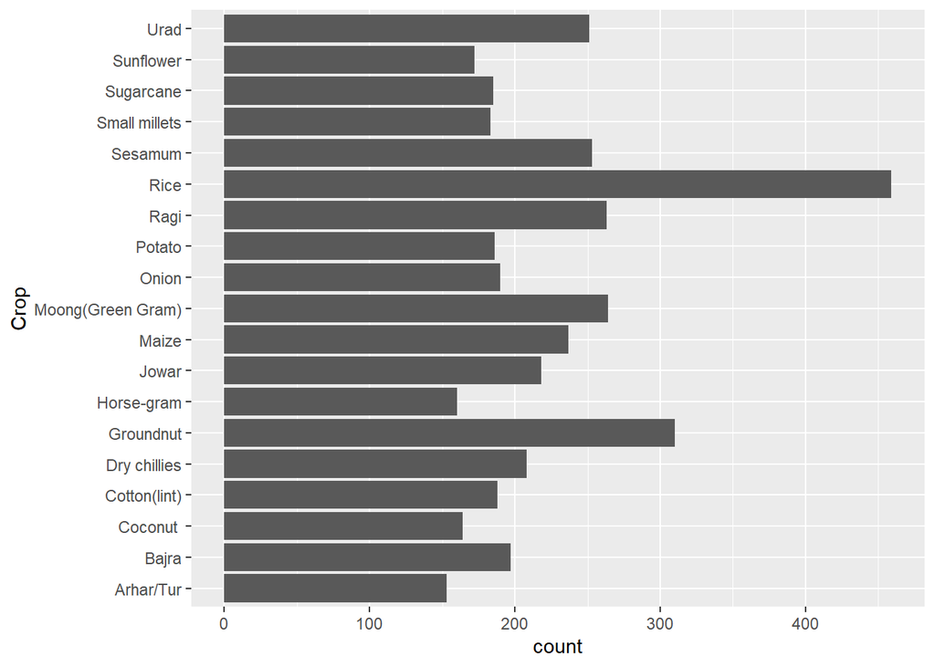

```r
newYear <- group_by(newYear, Crop_Year, State, Season, Crop)

newYear %>%
group_by(Crop) %>%
summarise(count = n()) -> cropNums

mainCrops <- filter(cropNums, count > 150)

ggplot(mainCrops, aes(x = Crop, y = count)) +
  geom_bar(stat = "identity") + coord_flip()
```

Rice is most popular as a kharif and rabi crop Crops and seasons seem to match nothing weird going on

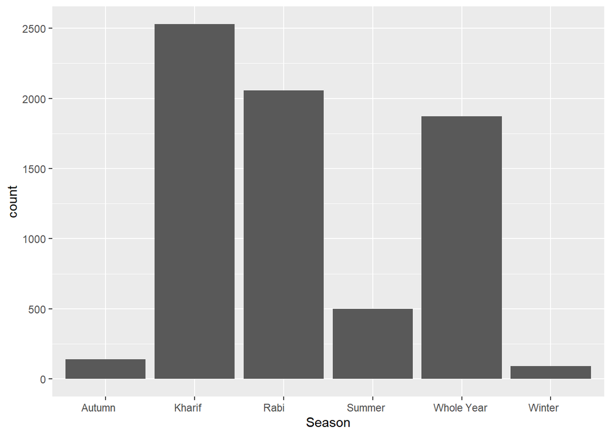

```r
riceStats <- filter(newYear, Crop == "Rice")

ggplot(newYear, aes(Season)) +
  geom_bar()
```

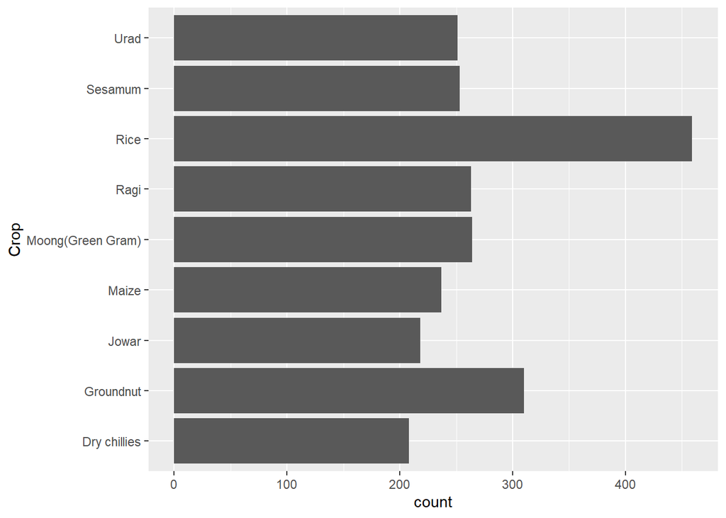

```r
mainCrops <- filter(cropNums, count > 200)

ggplot(mainCrops, aes(x = Crop, y = count)) +
  geom_bar(stat = "identity") + coord_flip()
```

filtering it down more

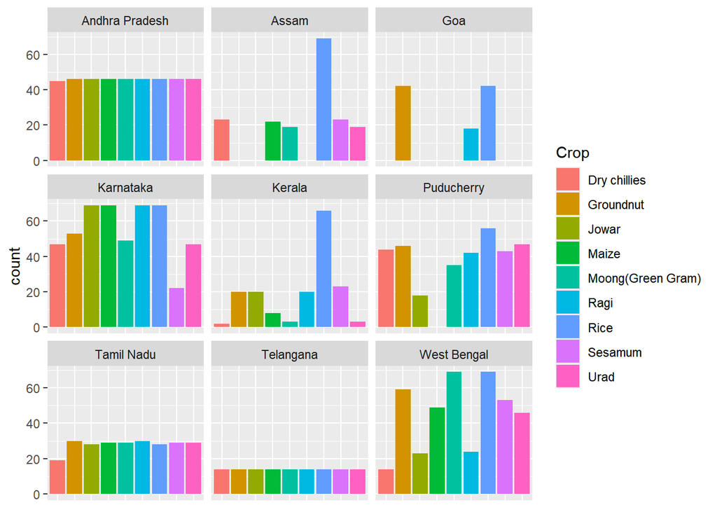

```r
CropNames <- c("Urad", "Sesamum", "Rice", "Ragi", "Moong(Green Gram)", "Maize", "Jowar", "Groundnut", "Dry chillies")
newYear <- filter(newYear, Crop %in% CropNames)

ggplot(newYear, aes(Crop, fill = Crop)) +
  geom_bar() + facet_wrap(~State) + theme(
    axis.title.x = element_blank(),
    axis.text.x = element_blank(),
    axis.ticks.x = element_blank()
  )
```

Interesting splits for Andhra, Tamil, and Telangana

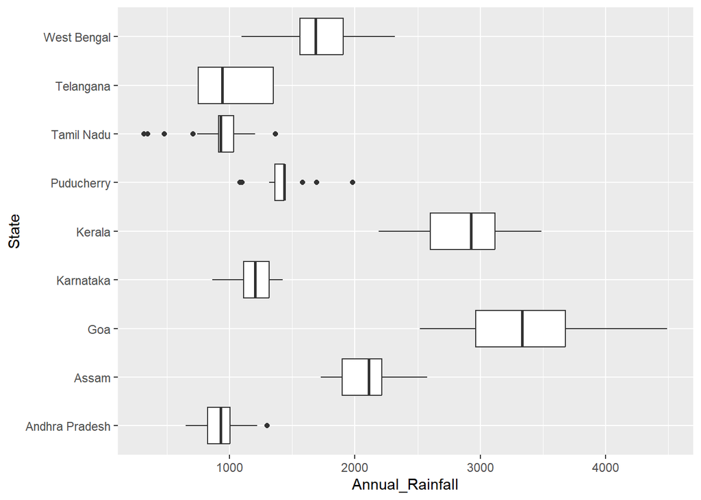

```r
ggplot(newYear, aes(State, Annual_Rainfall)) +
  geom_boxplot() + coord_flip()
```

Goa and Kerala have higher annual rainfall averages western and southern states have more rainfall so makes sense

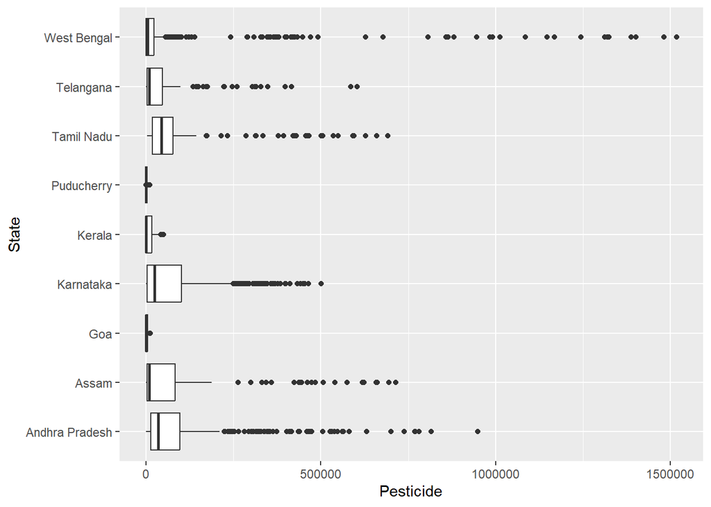

```r
ggplot(newYear, aes(State, Pesticide)) +
  geom_boxplot() + coord_flip()
```

The usage in West Bengal is funny to look at I wonder if they had infestations

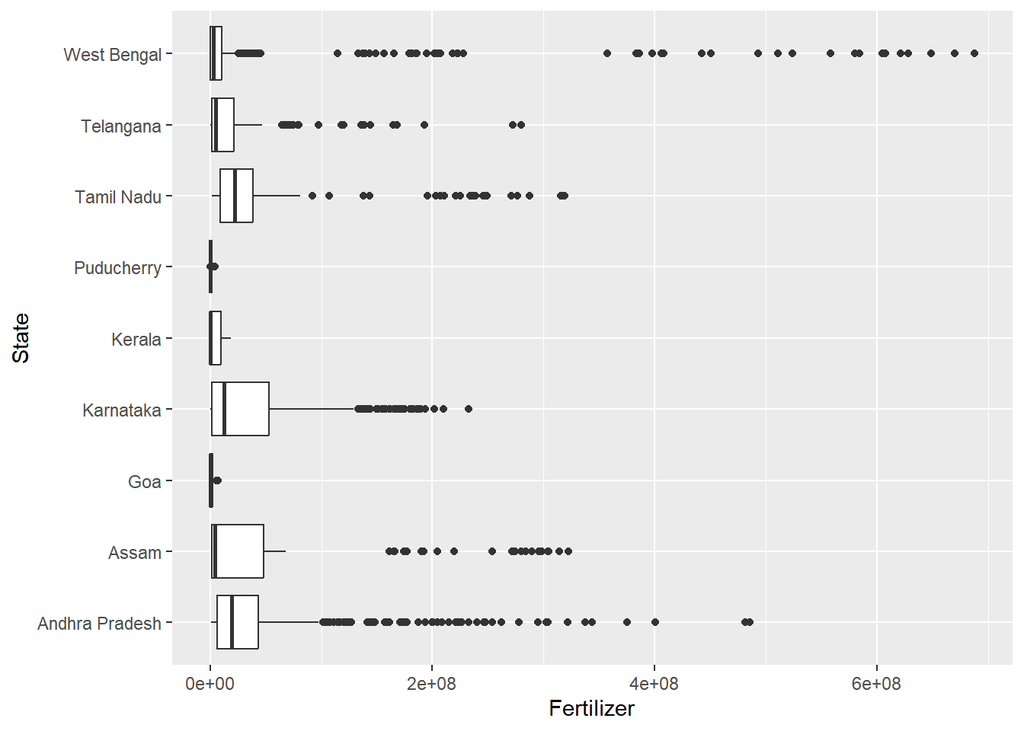

```r
ggplot(newYear, aes(State, Fertilizer)) +
  geom_boxplot() + coord_flip()
```

Low usage

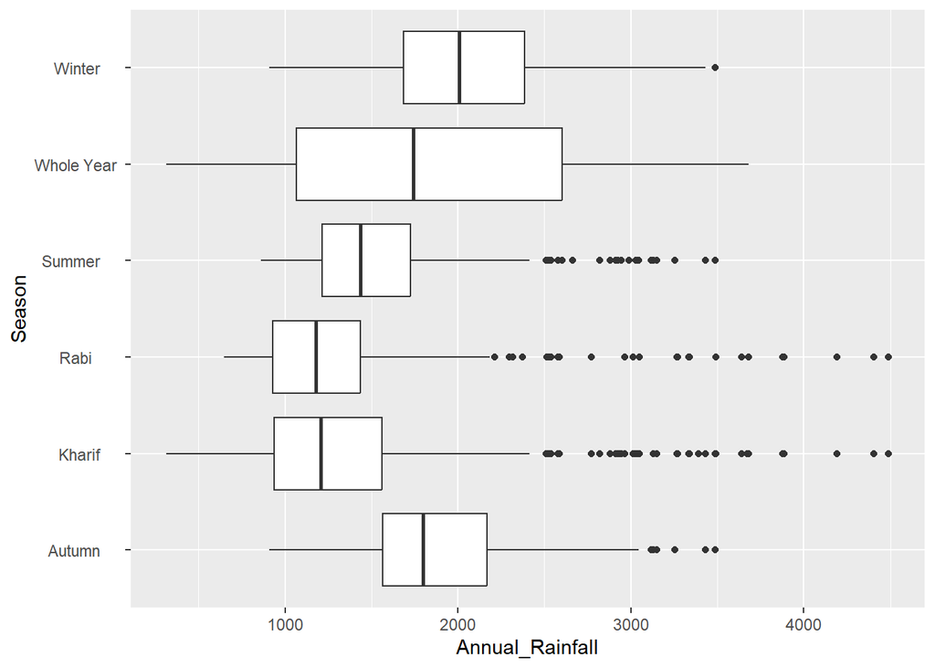

```r
ggplot(newYear, aes(Season, Annual_Rainfall)) +
  geom_boxplot() + coord_flip()
```

```r
ggsave("plot06.png")
```

```r
costNames <- c("Gururat", "Tamil Nadu", "Andhra Pradesh", "Maharashtra", "Kerala", "Odisha", "Karnataka", "Goa", "West Bengal")

Coastal <- replace(crop_yield$State, crop_yield$State %in% costNames, "Coastal State")
Coastal <- replace(crop_yield$State, !crop_yield$State %in% costNames, "non-Coastal State")

TwoState <- crop_yield
TwoState$State <- Coastal
Coastal <- replace(TwoState$State, TwoState$State %in% costNames, "Coastal State")

TwoState$State <- Coastal
```

filtering data and making the state column binary

```r
crop_regression <- lm(Yield ~ Annual_Rainfall, data = crop_yield)

summary(crop_regression)
```

```
##
## Call:
## lm(formula = Yield ~ Annual_Rainfall, data = crop_yield)
##
## Residuals:
##     Min      1Q  Median      3Q     Max
##  -193.7   -82.3   -73.2   -65.9 21040.5
##
## Coefficients:
##                  Estimate Std. Error t value Pr(>|t|)
## (Intercept)     47.861465  12.668446   3.778 0.000159 ***
## Annual_Rainfall  0.022321   0.007661   2.914 0.003577 **
## ---
## Signif. codes:  0 '***' 0.001 '**' 0.01 '*' 0.05 '.' 0.1 ' ' 1
##
## Residual standard error: 878.1 on 19687 degrees of freedom
## Multiple R-squared:  0.000431,   Adjusted R-squared:  0.0003802
## F-statistic: 8.489 on 1 and 19687 DF,  p-value: 0.003577
```

Low correlation (surprising)

```r
fert_regression <- lm(Yield ~ Fertilizer, data = crop_yield)

summary(fert_regression)
```

```
##
## Call:
## lm(formula = Yield ~ Fertilizer, data = crop_yield)
##
## Residuals:
##     Min      1Q  Median      3Q     Max
##  -206.6   -79.0   -78.5   -77.3 21025.7
##
## Coefficients:
##              Estimate Std. Error t value Pr(>|t|)
## (Intercept) 7.932e+01  6.458e+00  12.282   <2e-16 ***
## Fertilizer  2.647e-08  6.593e-08   0.402    0.688
## ---
## Signif. codes:  0 '***' 0.001 '**' 0.01 '*' 0.05 '.' 0.1 ' ' 1
##
## Residual standard error: 878.3 on 19687 degrees of freedom
## Multiple R-squared:  8.19e-06,   Adjusted R-squared:  -4.26e-05
## F-statistic: 0.1612 on 1 and 19687 DF,  p-value: 0.688
```

low correlation

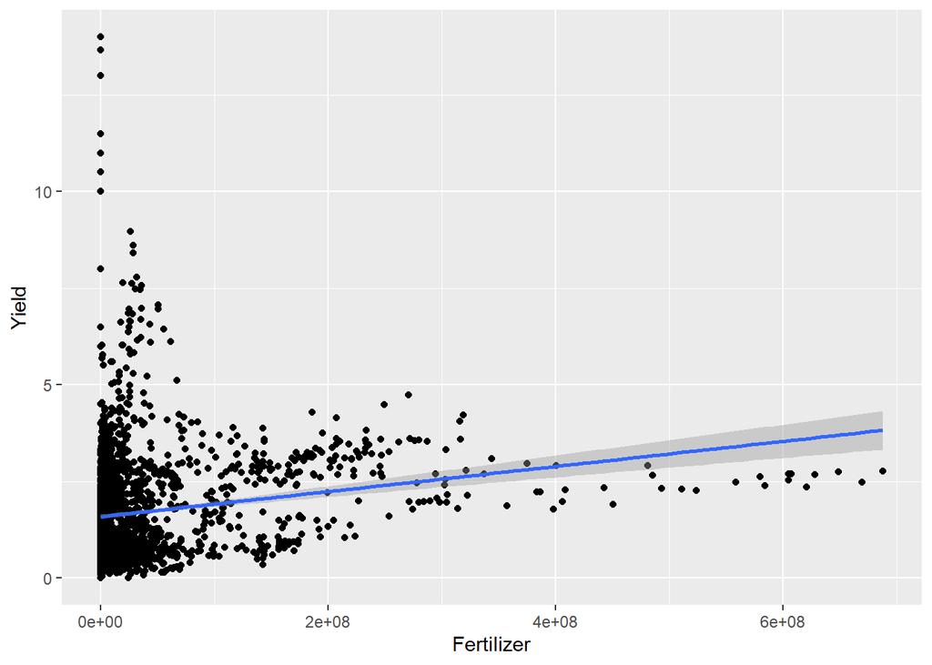

```r
ggplot(newYear, aes(Fertilizer, Yield)) +
  geom_point() +
  geom_smooth(method="lm")
```

does have correlation but it seems most states dont use much fertilizer

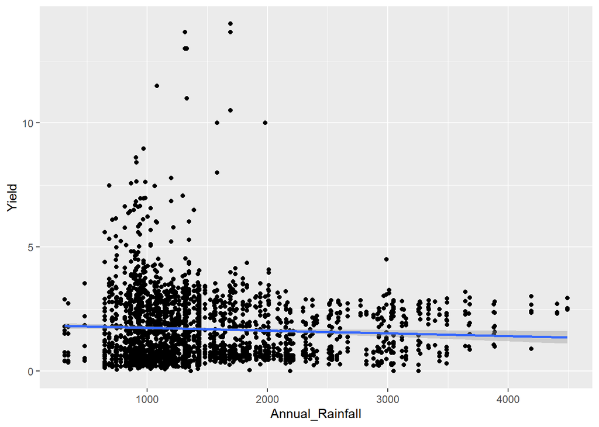

```r
ggplot(newYear, aes(Annual_Rainfall, Yield)) +
  geom_point() +
  geom_smooth(method="lm")
```

All states makes a odd plot Going to split them

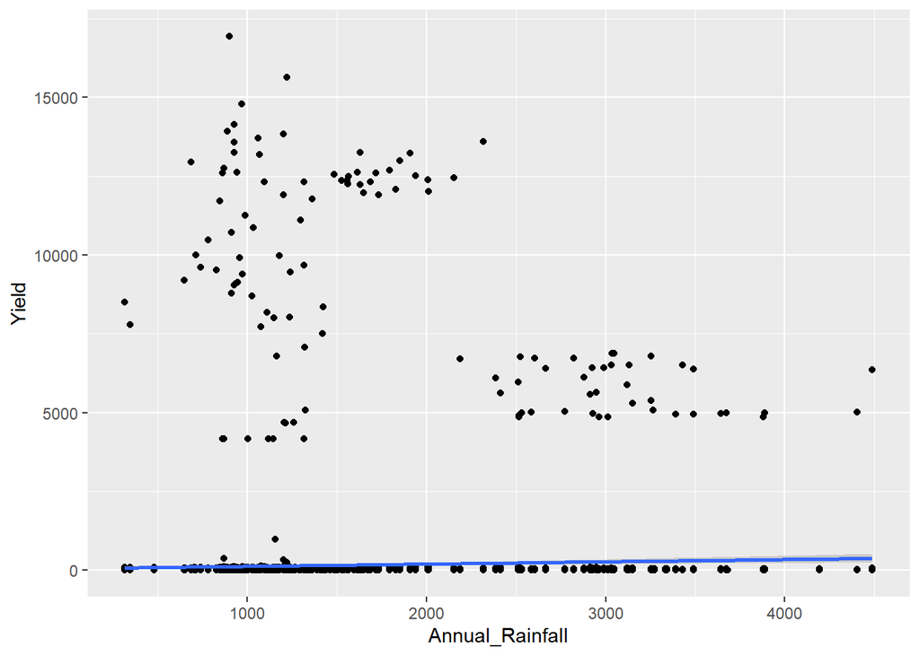

```r
CoastalStates <- filter(TwoState, State == "Coastal State")
NonCoastalStates <- filter(TwoState, State == "non-Coastal State")

ggplot(CoastalStates, aes(Annual_Rainfall, Yield)) +
  geom_point() +
  geom_smooth(method="lm")
```

Low correlation

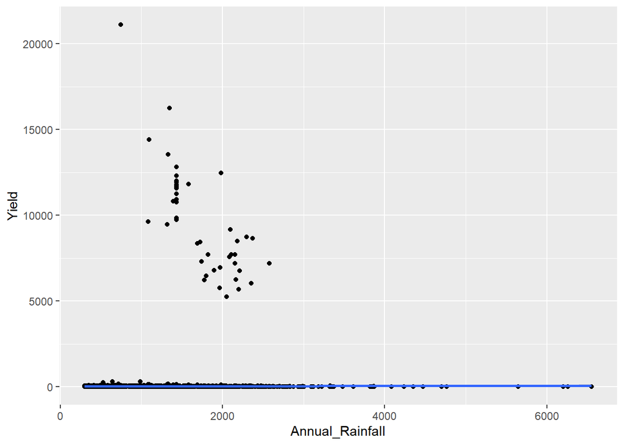

```r
ggplot(NonCoastalStates, aes(Annual_Rainfall, Yield)) +
  geom_point() +
  geom_smooth(method="lm")
```

Same trend

```r
t.test(Yield ~ State, data = TwoState)
```

```
##
##  Welch Two Sample t-test
##
## data:  Yield by State
## t = 7.7002, df = 8668.7, p-value = 1.507e-14
## alternative hypothesis: true difference in means between group Coastal State and group non-Coastal State is not equal to 0
## 95 percent confidence interval:
##   90.68099 152.61692
## sample estimates:
##     mean in group Coastal State mean in group non-Coastal State
##                       158.82287                        37.17391
```

Big difference in yield between coastal and non coastal states maybe due to rain? (low correlation though so it doesn’t explain it)

```r
t.test(Annual_Rainfall ~ State, data = TwoState)
```

```
##
##  Welch Two Sample t-test
##
## data:  Annual_Rainfall by State
## t = -1.7386, df = 17483, p-value = 0.08212
## alternative hypothesis: true difference in means between group Coastal State and group non-Coastal State is not equal to 0
## 95 percent confidence interval:
##  -41.771921   2.501321
## sample estimates:
##     mean in group Coastal State mean in group non-Coastal State
##                        1425.025                        1444.660
```

the difference in rain between coastal and non coastal is not significant and the correlation of rain to yield is really low. None of the data here can really explain the difference.

```r
cor.test(crop_yield$Yield, crop_yield$Annual_Rainfall, method = "spearman")
```

```
##
##  Spearman's rank correlation rho
##
## data:  crop_yield$Yield and crop_yield$Annual_Rainfall
## S = 1.213e+12, p-value = 7.095e-11
## alternative hypothesis: true rho is not equal to 0
## sample estimates:
##        rho
## 0.04643428
```

```r
cor.test(crop_yield$Yield, crop_yield$Fertilizer, method = "spearman")
```

```
##
##  Spearman's rank correlation rho
##
## data:  crop_yield$Yield and crop_yield$Fertilizer
## S = 1.1378e+12, p-value < 2.2e-16
## alternative hypothesis: true rho is not equal to 0
## sample estimates:
##       rho
## 0.1055509
```

```r
cor.test(crop_yield$Yield, crop_yield$Pesticide, method = "spearman")
```

```
##
##  Spearman's rank correlation rho
##
## data:  crop_yield$Yield and crop_yield$Pesticide
## S = 1.1392e+12, p-value < 2.2e-16
## alternative hypothesis: true rho is not equal to 0
## sample estimates:
##       rho
## 0.1044774
```

```r
cor(select(crop_yield, Annual_Rainfall, Pesticide, Fertilizer, Yield), method = "spearman")
```

```
##                 Annual_Rainfall  Pesticide Fertilizer      Yield
## Annual_Rainfall      1.00000000 -0.2676517 -0.2710585 0.04643428
## Pesticide           -0.26765165  1.0000000  0.9926065 0.10447741
## Fertilizer          -0.27105853  0.9926065  1.0000000 0.10555089
## Yield                0.04643428  0.1044774  0.1055509 1.00000000
```

Higher yields do have correlation with coastal states and non coastal states however the difference between them that could potentially explain the difference is not in this data set such as maybe different soil nutrients, humidity etc.

Looking into coastal states its most likely due to technology and being overall more developed due to ports.